# ab-test-analysis-executed

## 1. Setup & Data Pull

Load environment variables and pull experiment data from Supabase.

```
Analysis run: 2025-12-07 04:15:46
```

```
⚠ No .env file found
✓ Supabase URL: https://nazioidbiydxduonenmb.s...
```

```
✓ API helpers ready
```

```
✓ Loaded 347 events
  Date range: 2025-11-09 to 2025-11-28
  Event types: {'puzzle_started': 173, 'puzzle_completed': 122, 'puzzle_repeated': 26, 'puzzle_failed': 26}
```

```
📊 Analysis Datasets:
  Completions: 122 events
  Started: 173 events
  Repeated: 26 events

  Variant split (completions):
variant
B    73
A    49
```

```
📋 Data Quality Check:

Completion times range: 2.2s - 49.5s
Mean: 11.3s, Median: 7.4s

Null values in key columns:
variant                    0
completion_time_seconds    0
distinct_id                0
```

## 2. Exploratory Data Analysis

Understand the data distributions, identify outliers, and visualize key patterns before statistical testing.

```
📊 Sample Size by Variant

         n_completions  n_unique_users  avg_time  median_time  std_time
variant
A                   49               6    10.400        5.170    10.210
B                   73              12    11.920        8.820    10.050

  Total completions: 122
  Total unique users: 18
```

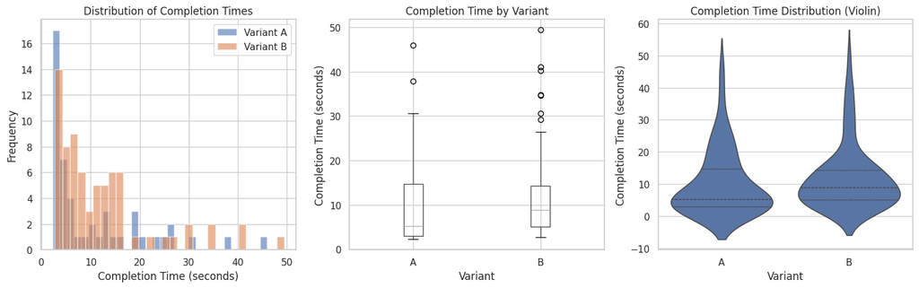

```
🔍 Outlier Analysis

Variant A:
  IQR: 11.7s
  Bounds: [0.0s, 32.1s]
  Outliers: 2 (4.1%)
  Outlier range: 37.9s - 46.0s

Variant B:
  IQR: 9.2s
  Bounds: [0.0s, 28.1s]
  Outliers: 7 (9.6%)
  Outlier range: 29.2s - 49.5s
```

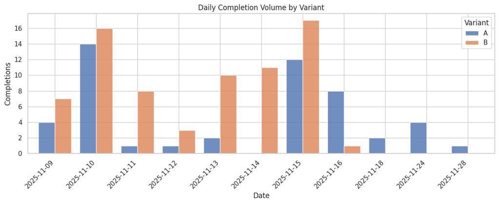

```
📅 Experiment Duration: 18 days
```

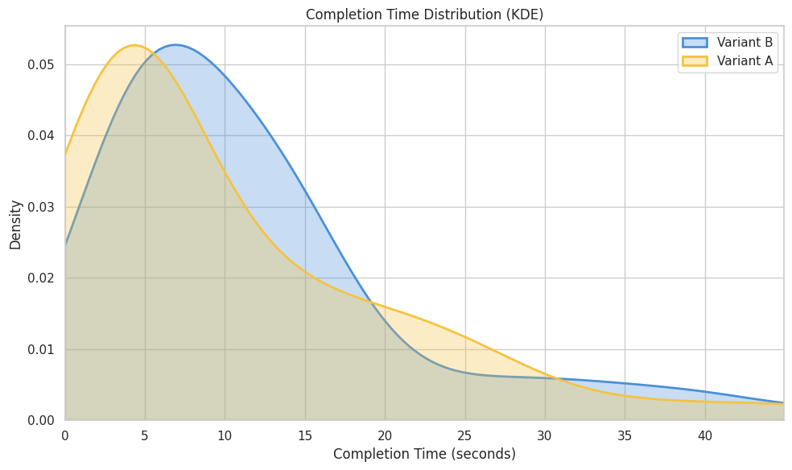

## 3. Hypothesis & Metrics Definition

### Experiment Context

The A/B Simulator is a **Pineapple Finder memory game** where users must memorize pineapple locations on a grid, then find them before the timer expires.

- **Variant A (Control):** 4 pineapples to find — baseline difficulty
- **Variant B (Treatment):** 5 pineapples to find — increased difficulty

### Hypotheses

**Primary Hypothesis (Completion Time):**

- **H₀:** μ_B = μ_A (No difference in mean completion time)
- **H₁:** μ_B > μ_A (Variant B takes longer to complete)
- **Rationale:** More pineapples to memorize = higher cognitive load = longer completion time

### Metrics Framework

| Metric | Type | Definition | Direction |
| --- | --- | --- | --- |
| **Completion Time** | Primary KPI | Time in seconds to find all pineapples | B > A expected |
| **Completion Rate** | Secondary/Guardrail | % of started games that complete | Monitor for drop |
| **Repeat Rate** | Engagement Guardrail | % of users who play again | Monitor engagement |

### Success Criteria

- **Statistical:** p < 0.05 (two-tailed for primary, one-tailed acceptable given directional hypothesis)
- **Practical:** Effect size Cohen's d > 0.2 (small but meaningful)
- **Guardrail:** Completion rate drop < 10% relative

```
📊 Metric Baselines

PRIMARY: Completion Time (seconds)
  Variant A: mean=10.40, std=10.21, n=49
  Variant B: mean=11.92, std=10.05, n=73
  Difference: 1.52s (14.6%)

SECONDARY: Completion Rate
  Variant A: 86.0% (49/57)
  Variant B: 62.9% (73/116)
  Difference: -23.0% (-26.8% relative)

ENGAGEMENT: Repeat Rate (repeats / completions)
  Variant A: 30.6% (15/49)
  Variant B: 15.1% (11/73)
```

## 4. Sanity Checks & QA

Before running statistical tests, validate data quality and check for Sample Ratio Mismatch (SRM).

```
🔍 Sample Ratio Mismatch (SRM) Test

Expected split: 50% / 50%
Observed split: 32.9% / 67.1%
  Variant A: 57 started
  Variant B: 116 started

Chi-square statistic: 20.1214
P-value: 0.0000

⚠️  WARNING: SRM detected (p < 0.01)
   Traffic allocation may be biased. Investigate before proceeding.
```

```
🔍 Data Quality Checks

                                    Check  Status                       Details
           No null values in variant/time  ✅ PASS 0 null variants, 0 null times
     No duplicate completions per session ⚠️ WARN           81 duplicates found
 Completion times in valid range (1-600s)  ✅ PASS      0 below 1s, 0 above 600s
Minimum sample size (n >= 30 per variant)  ✅ PASS          Smallest group: n=49
              Test ran for at least 1 day  ✅ PASS               18 days of data

==================================================
Overall: ⚠️ Some checks need attention
```

## 5. Primary Analysis: T-Test

Welch's t-test (unequal variances) comparing completion times between variants.

```
📊 Primary Analysis: Welch's T-Test

Testing: H₀: μ_B = μ_A vs H₁: μ_B ≠ μ_A

Sample Statistics:
  Variant A: n=49, mean=10.40s, std=10.21s
  Variant B: n=73, mean=11.92s, std=10.05s

Difference (B - A):
  Mean difference: 1.52s
  Relative change: 14.6%
  95% CI: [-2.19s, 5.24s]

Test Statistics:
  t-statistic: 0.8126
  Degrees of freedom (Welch): 102.0
  p-value (two-tailed): 0.4184
  p-value (one-tailed, B > A): 0.2092

Effect Size:
  Cohen's d: 0.151 (negligible)
```

```
📋 Statistical Decision

Significance level (α): 0.05
p-value: 0.4184

Decision: FAIL TO REJECT H₀ ⚠️

Conclusion: Insufficient evidence to conclude that
Variant B completion time differs from Variant A.

Observed difference of 1.52s could be due to chance.

==================================================
Practical Significance:
  Effect size (d=0.15) is below threshold for practical significance (d < 0.2).
```

## 6. Primary Analysis: Regression

OLS regression provides the same result as t-test but offers flexibility for covariate adjustment.

```
📊 OLS Regression Analysis

                               OLS Regression Results
===================================================================================
Dep. Variable:     completion_time_seconds   R-squared:                       0.006
Model:                                 OLS   Adj. R-squared:                 -0.003
Method:                      Least Squares   F-statistic:                    0.6643
Date:                     Sun, 07 Dec 2025   Prob (F-statistic):              0.417
Time:                             04:15:48   Log-Likelihood:                -454.43
No. Observations:                      122   AIC:                             912.9
Df Residuals:                          120   BIC:                             918.5
Df Model:                                1
Covariance Type:                 nonrobust
===================================================================================


==============================================================================
                 coef    std err          t      P>|t|      [0.025      0.975]
------------------------------------------------------------------------------
Intercept     10.3981      1.445      7.195      0.000       7.537      13.260
treatment      1.5228      1.868      0.815      0.417      -2.176       5.222
==============================================================================
```

```
📋 Regression Interpretation

Model: completion_time = β₀ + β₁ × treatment + ε

Coefficients:
  β₀ (Intercept): 10.40s
     → Mean completion time for Variant A

  β₁ (Treatment): 1.52s
     → Additional time for Variant B vs A
     → 95% CI: [-2.18s, 5.22s]
     → p-value: 0.4167

==================================================
Validation: Regression β₁ matches t-test difference
  T-test diff: 1.5228s
  Regression β₁: 1.5228s
  Match: ✅ Yes
```

## 7. Variance Reduction: CUPED Framework

**CUPED** (Controlled-experiment Using Pre-Experiment Data) reduces variance by adjusting for pre-experiment covariates.

**Formula:** Y_adjusted = Y - θ(X - X̄)

Where θ = Cov(Y, X) / Var(X)

> ⚠️ **Note:** This experiment lacks pre-experiment covariates. Below is a template demonstrating the CUPED framework using simulated data for educational purposes.

```
📊 CUPED Variance Reduction Demo

CUPED Parameters:
  θ (adjustment coefficient): 1.0884
  Correlation(Y, X): 0.774

Variance Comparison:
  Original variance: 102.06
  CUPED variance: 40.98
  Variance reduction: 59.9%
```

```
📊 CUPED-Adjusted Analysis

Comparison: Original vs CUPED-Adjusted

Metric                        Original        CUPED
--------------------------------------------------
Mean diff (B - A)                 1.52         1.21
Standard Error                    1.87         1.14
t-statistic                     0.8126       1.0542
p-value                         0.4184       0.2940

==================================================
SE Reduction: 39.0%

💡 In production with real pre-experiment data,
   CUPED typically reduces variance by 20-50%.
```

## 8. Secondary Metrics & Guardrails

Analyze conversion rates and engagement metrics to ensure the treatment doesn't harm user experience.

```
📊 Secondary Metric: Completion Rate

Contingency Table:
                   Completed   Not Completed
Variant A                 49               8
Variant B                 73              43

Completion Rates:
  Variant A: 86.0% (49/57)
  Variant B: 62.9% (73/116)
  Difference: -23.0% (-26.8% relative)

Chi-Square Test:
  χ² statistic: 8.6775
  p-value: 0.0032

⚠️  GUARDRAIL ALERT: Significant drop in completion rate!
```

```
📊 Engagement Guardrail: Repeat Rate

Repeat Rates:
  Variant A: 30.6% (15/49)
  Variant B: 15.1% (11/73)
  Difference: -15.5%

Two-Proportion Z-Test:
  z-statistic: -2.0553
  p-value: 0.0399

⚠️  GUARDRAIL ALERT: Significant drop in engagement!
```

```
📋 Secondary Metrics Summary

         Metric Variant A Variant B Difference p-value   Status
Completion Rate     86.0%     62.9%     -23.0%  0.0032 ⚠️ Alert
    Repeat Rate     30.6%     15.1%     -15.5%  0.0399 ⚠️ Alert

============================================================
Overall Guardrail Status: ⚠️ Review needed
```

## 9. Results Visualization

Visual confidence intervals and daily trend analysis.

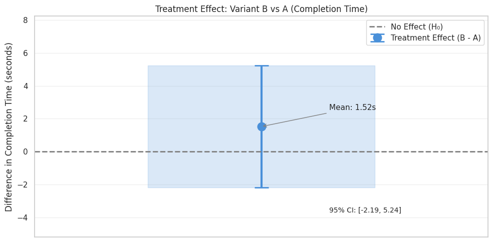

```
📊 Interpretation:
   The 95% CI [-2.19s, 5.24s] includes zero.
   → Cannot conclude a significant difference between variants.
```

```
📊 Daily Treatment Effect Over Time
```

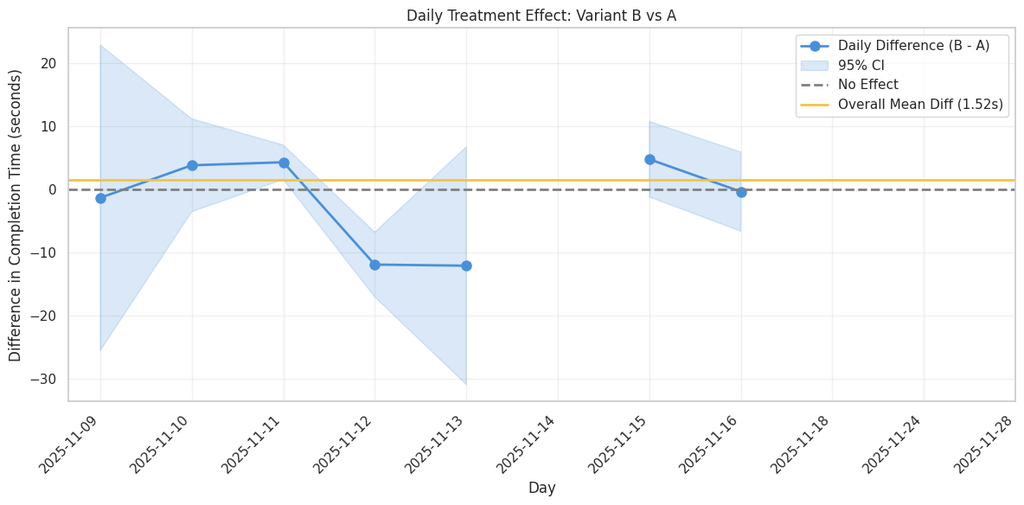

```
Days with positive effect (B > A): 3
Days with negative effect (B < A): 4
```

## 10. Post-Hoc Power Analysis

Assess the statistical power of this experiment and determine sample size requirements for future experiments.

```
📊 Post-Hoc Power Analysis

Current Experiment Parameters:
  Sample size A: 49
  Sample size B: 73
  Observed effect size (Cohen's d): 0.151
  Significance level (α): 0.05

Observed Statistical Power: 12.8%

⚠️  Experiment was UNDERPOWERED (< 80%)
   High risk of Type II error (false negative)
```

```
📊 Sample Size Requirements

Sample size per group needed for 80% power (α=0.05, two-sided):

Effect Size (d)        N per Group      Total N
------------------------------------------------
d = 0.2                        394          787
d = 0.3                        176          351
d = 0.5                         64          128
d = 0.8                         26           52

================================================
To detect observed effect (d=0.151) at 80% power:
  Need: 694 per group (1,388 total)
  Have: 49 per group (122 total)
  Gap:  645 more needed per group
```

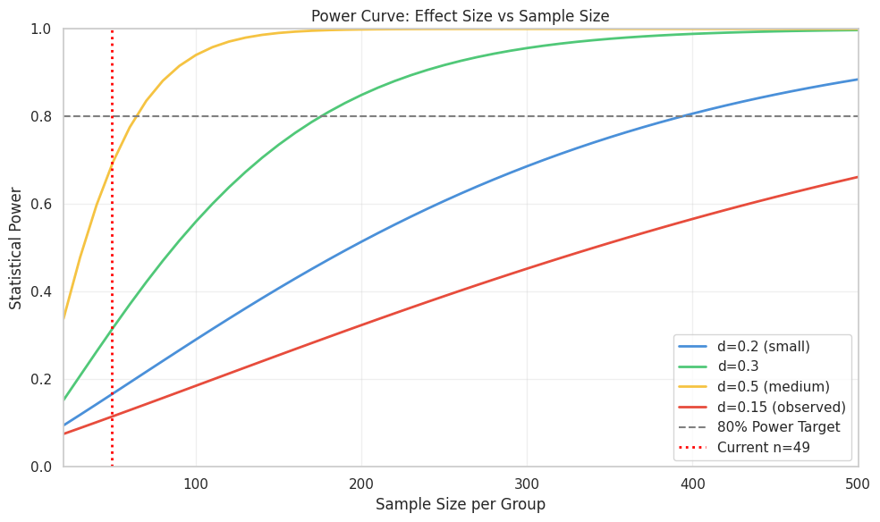

```
📊 Minimum Detectable Effect (MDE) at 80% power with n=49:
   Cohen's d = 0.572
   In seconds: 5.78s difference required
```

## 11. Conclusions & Recommendations

Executive summary of the A/B test analysis.

```
======================================================================
                    A/B TEST ANALYSIS: EXECUTIVE SUMMARY
======================================================================

EXPERIMENT: Pineapple Finder Memory Game
━━━━━━━━━━━━━━━━━━━━━━━━━━━━━━━━━━━━━━━━━━━━━━━━━━━━━━━━━━━━━━━━━━━━━━
  Variant A (Control):   4 pineapples to find
  Variant B (Treatment): 5 pineapples to find
  Duration:              18 days
  Total Completions:     122

PRIMARY METRIC: Completion Time
━━━━━━━━━━━━━━━━━━━━━━━━━━━━━━━━━━━━━━━━━━━━━━━━━━━━━━━━━━━━━━━━━━━━━━
  Variant A Mean:        10.40s (n=49)
  Variant B Mean:        11.92s (n=73)
  Difference:            +1.52s (+14.6%)
  95% CI:                [-2.19s, 5.24s]
  p-value:               0.4184
  Effect Size (d):       0.151

  RESULT: ❌ NOT SIGNIFICANT
          CI includes zero — cannot conclude a meaningful difference.

SECONDARY METRICS & GUARDRAILS
━━━━━━━━━━━━━━━━━━━━━━━━━━━━━━━━━━━━━━━━━━━━━━━━━━━━━━━━━━━━━━━━━━━━━━
  Completion Rate:       A=86.0% → B=62.9% (-26.8%)
                         p=0.0032 ⚠️ SIGNIFICANT DROP

  Repeat Rate:           A=30.6% → B=15.1% (-15.5%)
                         p=0.0399 ⚠️ SIGNIFICANT DROP

STATISTICAL POWER
━━━━━━━━━━━━━━━━━━━━━━━━━━━━━━━━━━━━━━━━━━━━━━━━━━━━━━━━━━━━━━━━━━━━━━
  Observed Power:        12.8% (target: 80%)
  MDE at n=49:          d=0.57 (5.8s)
  Sample needed for
  observed effect:       694 per group

======================================================================
```

```
📋 RECOMMENDATIONS
━━━━━━━━━━━━━━━━━━━━━━━━━━━━━━━━━━━━━━━━━━━━━━━━━━━━━━━━━━━━━━━━━━━━━━

1. DECISION: Do NOT ship Variant B

   While the primary metric (completion time) showed no significant difference,
   the guardrail metrics reveal concerning drops:
   • Completion rate dropped 23% (86% → 63%)
   • Repeat rate dropped 15.5 percentage points (31% → 15%)

   The treatment (5 pineapples) may be too difficult, causing users to:
   • Abandon the game before completing
   • Not return for additional plays

2. EXPERIMENT LIMITATIONS

   • Underpowered: Only 12.8% power to detect the observed effect
   • Sample Ratio Mismatch: 33%/67% split instead of 50/50
   • Small sample: n=122 total completions

3. NEXT STEPS

   a) If testing difficulty variations:
      • Try intermediate difficulty (4.5 pineapples via grid size)
      • Run longer to achieve adequate power (n ≈ 400 per group)

   b) If keeping current design:
      • Stick with Variant A (4 pineapples) as default
      • Monitor completion and repeat rates as key health metrics

   c) For future experiments:
      • Pre-calculate required sample size before launch
      • Implement proper 50/50 randomization
      • Consider CUPED with pre-experiment user metrics

━━━━━━━━━━━━━━━━━━━━━━━━━━━━━━━━━━━━━━━━━━━━━━━━━━━━━━━━━━━━━━━━━━━━━━
Analysis completed: 2025-12-07 04:15:49
━━━━━━━━━━━━━━━━━━━━━━━━━━━━━━━━━━━━━━━━━━━━━━━━━━━━━━━━━━━━━━━━━━━━━━
```